# Final Project Report

Daniel Seok Lee

May 4, 2021

How well are the players performing after signing multi-year contracts for millions of dollars?

Over the years, the NBA has been bringing in more revenue. This raises the net worth of teams which allows them to sign better players and bigger contracts. While the average player brings in a good amount of money, a superstar will sign multi-year contracts for millions of dollars.

In the summer of 2019, an NBA star, named Rudy Gobert, signed a five-year $205 million contract extension with the Utah Jazz. Shaquille O’Neal criticized Gobert’s game and claimed that he’s not worth that much.

I will investigate how well the top-earners of the league are performing compared to the rest of the league. I will use in-game statistics to determine the performance of the players to see if they are worth the money.

```r
#Set up
library(readr)
library(dplyr)
library(mosaic)
library(tidyverse)
library(ggplot2)
library(esquisse)
```

```r
#Reading in data files
NBA2020_2021Salaries <- read_csv("NBA2020:2021Salaries.csv")
NBAStats <- read_csv("NBAStats.csv")
StatsfromNBA <- read_csv("StatsfromNBA.csv")
Top50ofNBA <- read_csv("Top50ofNBA.csv")
```

```r
#Summary
summary(NBA2020_2021Salaries)
```

```
       #            Player              Salary
 Min.   :  1.0   Length:577         Min.   :   25000
 1st Qu.:145.0   Class :character   1st Qu.: 1517981
 Median :289.0   Mode  :character   Median : 2895720
 Mean   :287.1                      Mean   : 6752150
 3rd Qu.:409.0                      3rd Qu.: 8500000
 Max.   :576.0                      Max.   :43006362
```

```r
summary(NBAStats)
```

```
       Rk           Player              Pos                 Age
 Min.   :  1.0   Length:646         Length:646         Min.   :19.00
 1st Qu.:126.2   Class :character   Class :character   1st Qu.:23.00
 Median :254.0   Mode  :character   Mode  :character   Median :25.00
 Mean   :258.0                                         Mean   :25.83
 3rd Qu.:389.0                                         3rd Qu.:28.75
 Max.   :514.0                                         Max.   :37.00

      Tm                  G               GS              MP              FG
 Length:646         Min.   : 1.00   Min.   : 0.00   Min.   : 1.80   Min.   : 0.00
 Class :character   1st Qu.:14.00   1st Qu.: 0.00   1st Qu.:11.93   1st Qu.: 1.40
 Mode  :character   Median :31.00   Median : 4.00   Median :19.15   Median : 2.60
                    Mean   :28.47   Mean   :13.02   Mean   :19.33   Mean   : 3.16
                    3rd Qu.:43.00   3rd Qu.:24.00   3rd Qu.:27.38   3rd Qu.: 4.40
                    Max.   :53.00   Max.   :52.00   Max.   :37.30   Max.   :11.00

      FGA              FG%               3P              3PA              3P%
 Min.   : 0.000   Min.   :0.0000   Min.   :0.0000   Min.   : 0.000   Min.   :0.0000
 1st Qu.: 3.300   1st Qu.:0.3900   1st Qu.:0.2000   1st Qu.: 0.900   1st Qu.:0.2645
 Median : 5.800   Median :0.4370   Median :0.7000   Median : 2.200   Median :0.3420
 Mean   : 6.932   Mean   :0.4385   Mean   :0.9551   Mean   : 2.704   Mean   :0.3126
 3rd Qu.: 9.675   3rd Qu.:0.4940   3rd Qu.:1.5000   3rd Qu.: 4.200   3rd Qu.:0.3905
 Max.   :22.500   Max.   :1.0000   Max.   :4.7000   Max.   :11.500   Max.   :1.0000
                  NA's   :3                                          NA's   :39
       2P             2PA              2P%              eFG%              FT
 Min.   :0.000   Min.   : 0.000   Min.   :0.0000   Min.   :0.0000   Min.   : 0.000
 1st Qu.:0.800   1st Qu.: 1.600   1st Qu.:0.4440   1st Qu.:0.4710   1st Qu.: 0.400
 Median :1.600   Median : 3.200   Median :0.5090   Median :0.5190   Median : 0.900
 Mean   :2.205   Mean   : 4.231   Mean   :0.5049   Mean   :0.5038   Mean   : 1.342
 3rd Qu.:3.200   3rd Qu.: 5.900   3rd Qu.:0.5720   3rd Qu.:0.5670   3rd Qu.: 1.800
 Max.   :9.800   Max.   :16.000   Max.   :1.0000   Max.   :1.0000   Max.   :10.100
                                  NA's   :10       NA's   :3
      FTA              FT%              ORB              DRB              TRB
 Min.   : 0.000   Min.   :0.0000   Min.   :0.0000   Min.   : 0.000   Min.   : 0.000
 1st Qu.: 0.600   1st Qu.:0.6670   1st Qu.:0.3000   1st Qu.: 1.400   1st Qu.: 1.900
 Median : 1.300   Median :0.7745   Median :0.6000   Median : 2.400   Median : 3.100
 Mean   : 1.747   Mean   :0.7469   Mean   :0.7997   Mean   : 2.782   Mean   : 3.582
 3rd Qu.: 2.300   3rd Qu.:0.8500   3rd Qu.:1.0000   3rd Qu.: 3.700   3rd Qu.: 4.800
 Max.   :11.800   Max.   :1.0000   Max.   :4.8000   Max.   :10.000   Max.   :14.200
                  NA's   :36
      AST              STL              BLK              TOV              PF
 Min.   : 0.000   Min.   :0.0000   Min.   :0.0000   Min.   :0.000   Min.   :0.000
 1st Qu.: 0.700   1st Qu.:0.3000   1st Qu.:0.1000   1st Qu.:0.500   1st Qu.:1.100
 Median : 1.400   Median :0.6000   Median :0.3000   Median :0.900   Median :1.600
 Mean   : 1.939   Mean   :0.6059   Mean   :0.4155   Mean   :1.092   Mean   :1.627
 3rd Qu.: 2.500   3rd Qu.:0.9000   3rd Qu.:0.6000   3rd Qu.:1.500   3rd Qu.:2.100
 Max.   :11.000   Max.   :2.0000   Max.   :3.5000   Max.   :5.000   Max.   :4.500

      PTS
 Min.   : 0.000
 1st Qu.: 3.800
 Median : 6.950
 Mean   : 8.617
 3rd Qu.:12.000
 Max.   :31.200
```

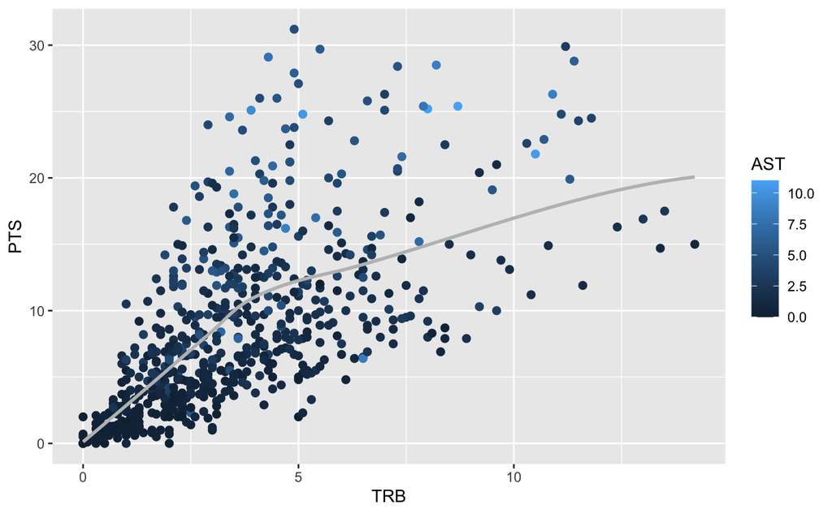

```r
NBAStats %>%
  ggplot(aes(x = TRB, y = PTS, colour = AST)) +
  geom_point(size=2) +
  geom_smooth(se=F, colour="grey")
```

```r
NBA2020_2021Salaries %>%
  summarise(avgsal = mean(Salary, na.rm = TRUE))
```

| avgsal |
| --- |
| 6752150 |

```r
NBAStats %>%
  summarise(avgpts = mean(PTS, na.rm = TRUE),
            avgast = mean(AST, na.rm = TRUE),
            avgtrb = mean(TRB, na.rm = TRUE))
```

| avgpts | avgast | avgtrb |
| --- | --- | --- |
| 8.616873 | 1.939009 | 3.581579 |

From the summarizes of these two tables, we can see that the average player is paid $6,752,150 for the season. The average player gets 8.6 points, 1.9 assists, and 3.6 rebounds.

```r
#Joining stats and salary of top 50 players
Top50 <-
  Top50ofNBA %>%
  select(Player, PTS, REB, AST, EFF) %>%
  left_join(NBA2020_2021Salaries %>% select(Player, Salary), by = c("Player" = "Player"))

#Average of top 50
Top50 %>%
  summarise(avgpts = mean(PTS, na.rm = TRUE),
            avgast = mean(AST, na.rm = TRUE),
            avgreb = mean(REB, na.rm = TRUE),
            avgeff = mean(EFF, na.rm = TRUE),
            avgsal = mean(Salary, na.rm = TRUE))
```

| avgpts | avgast | avgreb | avgeff | avgsal |
| --- | --- | --- | --- | --- |
| 22.12 | 5.152 | 6.032 | 22.75 | 21856485 |

In the middle of the NBA season, the league holds an All-Star Break. One of the events and the biggest one is the All-Star game. This game involves about 24 of the top players of the league. Captains are chosen through voting by the fans. So let’s see how the top 22 compare to the rest of the league statistically.

Efficiency is calculated by the formula: (PTS + REB + AST + STL + BLK − Missed FG − Missed FT - TO) / GP. It is used to determine how well a player is playing and who deserves to be crowned MVP at the end of the regular season.

```r
Top22 <-
  Top50ofNBASal %>%
    filter(EFF > 22.75) %>%
    arrange(desc(EFF))
Top22
```

| Player | PTS | REB | AST | EFF | Salary |
| --- | --- | --- | --- | --- | --- |
| Nikola Jokic | 26.2 | 10.9 | 8.5 | 36.1 | 29542010 |
| Giannis Antetokounmpo | 28.4 | 11.1 | 5.9 | 33.4 | 27528088 |
| Luka Doncic | 28.6 | 8.0 | 8.9 | 30.0 | 8049360 |
| Stephen Curry | 31.3 | 5.5 | 5.8 | 29.2 | 43006362 |
| Russell Westbrook | 21.8 | 11.3 | 11.2 | 28.4 | 41358814 |
| Nikola Vucevic | 23.8 | 11.5 | 3.7 | 28.2 | 26000000 |
| Domantas Sabonis | 20.2 | 11.9 | 6.2 | 28.2 | 19800000 |
| Kawhi Leonard | 25.5 | 6.6 | 5.1 | 28.0 | 34379100 |
| Jimmy Butler | 21.5 | 7.0 | 7.2 | 27.7 | 34379100 |
| Zion Williamson | 27.0 | 7.1 | 3.7 | 27.6 | 10245480 |

[output cut: 12 more lines]

So I filtered the data so that we only get players whose efficiency are better than the average Top 50, 22.75.

Just from looking at the top 10, we can see that Luka Doncic isn’t being paid as much and the rest of the players. And Rudy Gobert isn’t even on the list.

Shaquille O’Neal may have a point when he says that Rudy Gobert is not worth that much.

[figure not shown]

```r
Top22 %>%
  ggplot(aes(x = Player, weight = EFF)) +
  geom_bar(fill = "#0c4c8a") +
  theme_minimal()
```

```r
TopPlayers <-
  Top22 %>%
    select(Player, PTS, REB, AST, EFF) %>%
    filter( PTS > 25, REB > 5, AST > 5)

TopPlayers %>%
  pivot_longer(!Player, names_to = "Stat", values_to = "count")
```

| Player | Stat | count |
| --- | --- | --- |
| Nikola Jokic | PTS | 26.2 |
| Nikola Jokic | REB | 10.9 |
| Nikola Jokic | AST | 8.5 |
| Nikola Jokic | EFF | 36.1 |
| Giannis Antetokounmpo | PTS | 28.4 |
| Giannis Antetokounmpo | REB | 11.1 |
| Giannis Antetokounmpo | AST | 5.9 |
| Giannis Antetokounmpo | EFF | 33.4 |
| Luka Doncic | PTS | 28.6 |
| Luka Doncic | REB | 8.0 |

[output cut: 14 more lines]

This table shows some of the best rounded players and who to build a team around.